# Early subjective-discount calculations — reproducible reconstruction

This file reconstructs the early full-contract subjective-discount calculations discussed in the chat.

Important distinction. `simulations_PVs_audit_v1_original.Rmd` is the older audit file and uses the simplified common-threshold loan model. The 3% to 30% subjective-discount sweep was not originally written into that RMD. This file makes that later calculation explicit and reproducible.

The reconstruction uses:

- `wages.xlsx`, sheet `main_df`
- `betas_saturated_model.xlsx`, sheet `main`
- the official GOV.UK **2021-22** Plan 2 overseas-threshold table (published 19 May 2021; applies April 2021 to March 2022), restricted to the EU, EEA and EFTA
- World Bank indicator `NY.GDP.PCAP.PP.KD`, year 2022, only for the optional GDP-gradient section

The early calculation assumes the 2021-22 country thresholds remain fixed over the simulated 30-year horizon. It also assumes constant RPI of 4.3%, nominal wage growth of 2%, and no application-to-first-repayment lag. Those are calibration choices, not estimates.

**Note on the threshold vintage.** An earlier version of this file used the 2025-26 table. The 2021-22 table is not a simple rescaling of it: several countries sit in a different band entirely. Greece and Portugal are one band higher in 2021-22, France and Denmark are one band higher, and Switzerland occupies a top band that has no counterpart in the earlier hard-coded set. Results are therefore expected to differ from the 2025-26 run, and the differences are substantive rather than a rounding artefact.

```r
library(readxl)
library(dplyr)
library(tidyr)
library(sandwich)
library(lmtest)
library(ggplot2)
library(scales)

L <- 9250
Ppost <- 22200
alpha <- 0.09
wage_growth <- 0.02
rpi <- 0.043
interest_spread <- 0.03
horizon <- 30

# Eurostat wages are already expressed in euros for every country.
# Therefore the relevant conversion is EUR -> GBP, not each country's local-currency rate.
#
# The 2021-22 GOV.UK table publishes its own Euro rate (0.885798). Using that rate
# keeps the wage conversion and the thresholds on the same vintage. The 0.848248
# figure below belongs to the 2025-26 run and is retained only for comparison.
eur_gbp_2021_22 <- 0.885798
eur_gbp_2025_26 <- 0.848248

eur_gbp <- eur_gbp_2021_22
```

# 1. Official 2021-22 Plan 2 overseas thresholds, EU / EEA / EFTA

Lower and upper thresholds are transcribed from the GOV.UK guidance “Overseas earnings thresholds for Plan 2 student loans, 2021-22” (updated 19 May 2021).

`Country` uses the Eurostat spelling so that it joins to `wages.xlsx`. Where GOV.UK uses a different label, the source label is recorded in `govuk_name`.

`bloc` records membership: `EU` for member states, `EEA-EFTA` for Iceland, Liechtenstein and Norway (in both the EEA and EFTA), and `EFTA` for Switzerland, which is in EFTA but not the EEA.

```r
thresholds <- tribble(
  ~Country,        ~iso2c, ~govuk_name,      ~bloc,      ~lower, ~upper,
  # --- EU member states ---
  "Austria",       "AT", NA_character_,      "EU",        27295,  49130,
  "Belgium",       "BE", NA_character_,      "EU",        27295,  49130,
  "Bulgaria",      "BG", NA_character_,      "EU",        10920,  19655,
  "Croatia",       "HR", NA_character_,      "EU",        16380,  29480,
  "Cyprus",        "CY", NA_character_,      "EU",        21840,  39305,
  "Czechia",       "CZ", "Czech Republic",   "EU",        16380,  29480,
  "Denmark",       "DK", NA_character_,      "EU",        32755,  58960,
  "Estonia",       "EE", NA_character_,      "EU",        21840,  39305,
  "Finland",       "FI", NA_character_,      "EU",        27295,  49130,
  "France",        "FR", NA_character_,      "EU",        27295,  49130,
  "Germany",       "DE", NA_character_,      "EU",        27295,  49130,
  "Greece",        "GR", NA_character_,      "EU",        21840,  39305,
  "Hungary",       "HU", NA_character_,      "EU",        16380,  29480,
  "Ireland",       "IE", NA_character_,      "EU",        27295,  49130,
  "Italy",         "IT", NA_character_,      "EU",        21840,  39305,
  "Latvia",        "LV", NA_character_,      "EU",        16380,  29480,
  "Lithuania",     "LT", NA_character_,      "EU",        16380,  29480,
  "Luxembourg",    "LU", NA_character_,      "EU",        27295,  49130,
  "Malta",         "MT", NA_character_,      "EU",        21840,  39305,
  "Netherlands",   "NL", NA_character_,      "EU",        27295,  49130,
  "Poland",        "PL", NA_character_,      "EU",        16380,  29480,
  "Portugal",      "PT", NA_character_,      "EU",        21840,  39305,
  "Romania",       "RO", NA_character_,      "EU",        10920,  19655,
  "Slovakia",      "SK", NA_character_,      "EU",        16380,  29480,
  "Slovenia",      "SI", NA_character_,      "EU",        21840,  39305,
  "Spain",         "ES", NA_character_,      "EU",        21840,  39305,
  "Sweden",        "SE", NA_character_,      "EU",        27295,  49130,
  # --- EEA-EFTA (EEA members outside the EU) ---
  "Iceland",       "IS", NA_character_,      "EEA-EFTA",  32755,  58960,
  "Liechtenstein", "LI", NA_character_,      "EEA-EFTA",  27295,  49130,
  "Norway",        "NO", NA_character_,      "EEA-EFTA",  32755,  58960,
  # --- EFTA only (not in the EEA) ---
  "Switzerland",   "CH", NA_character_,      "EFTA",      38215,  68785
)

# Band structure of the 2021-22 table, for reference.
thresholds %>%
  count(lower, upper, name = "countries_in_band") %>%
  arrange(lower)
```

| lower | upper | countries_in_band |
| --- | --- | --- |
| 10920 | 19655 | 2 |
| 16380 | 29480 | 7 |
| 21840 | 39305 | 8 |
| 27295 | 49130 | 10 |
| 32755 | 58960 | 3 |
| 38215 | 68785 | 1 |

Switzerland is the only country in the whole 2021-22 table on the top band of £38,215 / £68,785, so it will sit well outside the range of the other cases and is worth checking for leverage in section 8.

# 2. Input data

## 2a. Country-name harmonisation

The three sources do not agree on country labels. Eurostat writes `Czechia`, the saturated-model beta file writes `Czech Republic` and `Cyprus (European Union)`, and GOV.UK writes `Czech Republic`. Joining on the raw strings silently drops Cyprus and Czechia at the beta join and gives a 23-country sample instead of 25.

`canonical_country()` normalises all three sides to one spelling. It strips any trailing parenthetical qualifier first, which handles `Cyprus (European Union)` and Eurostat’s `Germany (until 1990 former territory of the FRG)` generically, then applies an explicit map for the remaining variants.

```r
canonical_country <- function(x) {
  x <- trimws(as.character(x))
  x <- sub("\\s*\\([^()]*\\)\\s*$", "", x)   # drop trailing "( ... )" qualifier
  x <- trimws(x)

  variant_map <- c(
    "Czech Republic"  = "Czechia",
    "Czech Rep."      = "Czechia",
    "Slovak Republic" = "Slovakia",
    "Holland"         = "Netherlands",
    "Hellas"          = "Greece",
    "Republic of Ireland" = "Ireland",
    "Swiss Confederation" = "Switzerland",
    "Kingdom of Norway"   = "Norway"
  )

  hit <- match(x, names(variant_map))
  ifelse(is.na(hit), x, unname(variant_map[hit]))
}

# Show exactly which labels the harmoniser rewrites, so nothing is silent.
report_relabels <- function(raw, source_name) {
  tibble(source = source_name, raw = unique(raw)) %>%
    mutate(canonical = canonical_country(raw)) %>%
    filter(raw != canonical)
}
```

## 2b. Load and join

```r
wages_raw <- read_excel("wages.xlsx", sheet = "main_df")
betas_raw <- read_excel("betas_saturated_model.xlsx", sheet = "main")

relabels <- bind_rows(
  report_relabels(wages_raw$Country, "wages.xlsx"),
  report_relabels(betas_raw$Country, "betas_saturated_model.xlsx")
)

relabels
```

| source | raw | canonical |
| --- | --- | --- |
| wages.xlsx | European Union - 27 countries (from 2020) | European Union - 27 countries |
| wages.xlsx | Euro area – 20 countries (2023-2025) | Euro area – 20 countries |
| betas_saturated_model.xlsx | Cyprus (European Union) | Cyprus |
| betas_saturated_model.xlsx | Czech Republic | Czechia |

```r
wages <- wages_raw %>%
  mutate(Country = canonical_country(Country)) %>%
  inner_join(thresholds, by = "Country") %>%
  mutate(wage_gbp = Wage_EURO * eur_gbp)

betas <- betas_raw %>%
  mutate(
    Country = canonical_country(Country),
    Estimate_TWFE = as.numeric(Estimate_TWFE),
    Estimate_controls = as.numeric(Estimate_controls),
    Estimate_Pooled = as.numeric(Estimate_Pooled)
  )

# The confidence bands in section 8c are sharper if the workbook carries a
# standard error for the controls specification, because the elasticities are a
# generated quantity: eta_j = beta_hat_j / k_j inherits the sampling error in
# beta_hat_j. Look for such a column rather than assuming one exists.
se_col_controls <- names(betas_raw)[
  grepl("controls", names(betas_raw), ignore.case = TRUE) &
  grepl("(^|[^a-z])se([^a-z]|$)|std|error", names(betas_raw), ignore.case = TRUE)
]

if (length(se_col_controls) >= 1) {
  betas$SE_controls <- as.numeric(betas_raw[[se_col_controls[1]]])
  message("Using '", se_col_controls[1],
          "' as the standard error on Estimate_controls.")
} else {
  message("No standard-error column found for Estimate_controls. ",
          "Bands in section 8c will condition on the point estimates.")
}
```

```
## No standard-error column found for Estimate_controls. Bands in section 8c will condition on the point estimates.
```

```r
dat <- wages %>%
  left_join(
    betas[, intersect(
      c(
        "Country",
        "Estimate_TWFE",
        "Estimate_controls",
        "Estimate_Pooled",
        "SE_controls"
      ),
      names(betas)
    )],
    by = "Country"
  ) %>%
  filter(!is.na(Estimate_TWFE))
```

The country set is no longer the EU-only set used in the 2025-26 run, so the old `stopifnot(nrow(dat) == 25)` assertion is replaced by an explicit coverage report. Eurostat wage coverage for Iceland, Liechtenstein, Norway and Switzerland is not guaranteed, and a missing beta will silently drop a country at the filter above.

```r
coverage <- thresholds %>%
  mutate(
    survived_wage_join = Country %in% wages$Country,
    in_betas           = Country %in% betas$Country,
    in_final           = Country %in% dat$Country
  )

coverage %>%
  filter(!in_final) %>%
  select(Country, bloc, survived_wage_join, in_betas)
```

| Country | bloc | survived_wage_join | in_betas |
| --- | --- | --- | --- |
| Ireland | EU | TRUE | FALSE |
| Netherlands | EU | FALSE | TRUE |
| Iceland | EEA-EFTA | FALSE | FALSE |
| Liechtenstein | EEA-EFTA | FALSE | FALSE |
| Norway | EEA-EFTA | FALSE | FALSE |
| Switzerland | EFTA | FALSE | FALSE |

```r
dat %>% count(bloc, name = "n_countries")
```

| bloc | n_countries |
| --- | --- |
| EU | 25 |

```r
cat("Countries entering the sweep:", nrow(dat), "\n")
```

```
## Countries entering the sweep: 25
```

```r
# Expected sample: EU27, less Netherlands (no Eurostat wage) and Ireland
# (donor country, no treatment coefficient). Norway and Switzerland are also
# donors and correctly carry no beta, so they drop here by construction rather
# than by accident. A count below 25 means a label has drifted again.
expected_n <- 25
expected_missing <- c("Netherlands", "Ireland")

# Cyprus and Czechia are the two confirmed label mismatches: the beta workbook
# writes "Cyprus (European Union)" and "Czech Republic". They are the reason the
# sample was 23 rather than 25. Assert them by name so the harmoniser cannot
# silently regress.
label_casualties <- c("Cyprus", "Czechia")
missing_casualties <- setdiff(label_casualties, dat$Country)

if (length(missing_casualties) > 0) {
  stop(
    "canonical_country() failed on: ",
    paste(missing_casualties, collapse = ", "), ".\n",
    "Raw labels seen in the beta file: ",
    paste(sort(unique(betas_raw$Country[
      grepl("Cypr|Czech", betas_raw$Country, ignore.case = TRUE)
    ])), collapse = " | "), "\n",
    "Raw labels seen in the wage file: ",
    paste(sort(unique(wages_raw$Country[
      grepl("Cypr|Czech", wages_raw$Country, ignore.case = TRUE)
    ])), collapse = " | "),
    call. = FALSE
  )
}

unexpected_drops <- setdiff(
  coverage$Country[!coverage$in_final & coverage$bloc == "EU"],
  expected_missing
)

if (length(unexpected_drops) > 0) {
  warning(
    "EU countries dropped for reasons other than known missing data: ",
    paste(unexpected_drops, collapse = ", "),
    ". Check canonical_country() against the raw labels.",
    call. = FALSE
  )
}

if (nrow(dat) != expected_n) {
  message("Sample is ", nrow(dat), ", expected ", expected_n,
          ". See the coverage table above.")
}

# Fail loudly only on the things that would invalidate the run.
stopifnot(
  nrow(dat) > 0,
  !any(duplicated(dat$Country)),
  all(dat$lower < dat$upper)
)
```

# 3. Full-contract repayment stream

The loan balance earns contractual interest. The interest rate is RPI plus an income-dependent loading between 0 and 3 percentage points.

```r
loan_cashflows <- function(
    y0,
    lower,
    upper,
    L = 9250,
    alpha = 0.09,
    wage_growth = 0.02,
    rpi = 0.043,
    interest_spread = 0.03,
    horizon = 30) {

  balance <- L
  out <- vector("list", horizon)

  for (t in seq_len(horizon)) {

    earnings <- y0 * (1 + wage_growth)^(t - 1)

    loading <- if (earnings <= lower) {
      0
    } else if (earnings >= upper) {
      1
    } else {
      (earnings - lower) / (upper - lower)
    }

    contract_rate <- rpi + interest_spread * loading

    balance_after_interest <- balance * (1 + contract_rate)

    scheduled_repayment <- alpha * max(0, earnings - lower)
    payment <- min(scheduled_repayment, balance_after_interest)

    end_balance <- balance_after_interest - payment

    out[[t]] <- data.frame(
      t = t,
      earnings = earnings,
      loading = loading,
      contract_rate = contract_rate,
      scheduled_repayment = scheduled_repayment,
      payment = payment,
      end_balance = end_balance
    )

    balance <- end_balance

    if (balance <= 1e-10) break
  }

  bind_rows(out)
}
```

# 4. Subjective present value

This is the key change. The contractual repayment stream is generated first. Then the same cash flows are discounted using a subjective discount rate `rho`.

The early calculation did not add a separate lag from the application date to the first repayment year. Therefore year 1 of the simulated repayment stream is discounted by one period.

```r
subjective_pv <- function(y0, lower, upper, rho) {

  cf <- loan_cashflows(
    y0 = y0,
    lower = lower,
    upper = upper,
    L = L,
    alpha = alpha,
    wage_growth = wage_growth,
    rpi = rpi,
    interest_spread = interest_spread,
    horizon = horizon
  )

  sum(cf$payment / (1 + rho)^cf$t)
}
```

# 5. Reproduce the subjective-discount sweep

```r
rho_grid <- c(0.03, 0.05, 0.075, 0.10, 0.125, 0.15, 0.20, 0.25, 0.30)

results <- crossing(
  iso2c = dat$iso2c,
  rho = rho_grid
) %>%
  left_join(dat, by = "iso2c") %>%
  rowwise() %>%
  mutate(
    PV_subjective = subjective_pv(
      y0 = wage_gbp,
      lower = lower,
      upper = upper,
      rho = rho
    ),
    k_i = log(Ppost) - log(PV_subjective),
    eta_TWFE = Estimate_TWFE / k_i,
    eta_controls = Estimate_controls / k_i,
    eta_Pooled = Estimate_Pooled / k_i
  ) %>%
  ungroup()

sweep_summary <- results %>%
  group_by(rho) %>%
  summarise(
    n = n(),
    mean_PV = mean(PV_subjective),
    mean_eta_TWFE = mean(eta_TWFE),
    mean_eta_controls = mean(eta_controls),
    median_eta_controls = median(eta_controls),
    .groups = "drop"
  )

sweep_summary
```

| rho | n | mean_PV | mean_eta_TWFE | mean_eta_controls | median_eta_controls |
| --- | --- | --- | --- | --- | --- |
| 0.030 | 25 | 11294.007 | -1.8403053 | -1.7416100 | -1.3239066 |
| 0.050 | 25 | 9346.132 | -1.3535670 | -1.2832778 | -1.1651627 |
| 0.075 | 25 | 7628.659 | -1.0678444 | -1.0135998 | -1.0103881 |
| 0.100 | 25 | 6418.236 | -0.9057086 | -0.8603380 | -0.8409390 |
| 0.125 | 25 | 5530.798 | -0.7992789 | -0.7596342 | -0.7136568 |
| 0.150 | 25 | 4857.167 | -0.7233676 | -0.6877539 | -0.6300030 |
| 0.200 | 25 | 3907.501 | -0.6214227 | -0.5911435 | -0.5399746 |
| 0.250 | 25 | 3271.395 | -0.5555153 | -0.5286285 | -0.4802479 |
| 0.300 | 25 | 2814.992 | -0.5090389 | -0.4845130 | -0.4373911 |

## Legacy 2025-26 benchmark

```r
expected <- tibble(
  rho = c(0.03, 0.05, 0.075, 0.10, 0.125, 0.15, 0.20, 0.25, 0.30),
  expected_mean_PV = c(
    11101.60, 9029.17, 7236.57, 5999.04, 5108.92,
    4444.80, 3528.03, 2927.91, 2504.41
  ),
  expected_mean_eta_controls = c(
    -1.6511, -1.2117, -0.9519, -0.8046, -0.7082,
    -0.6398, -0.5484, -0.4897, -0.4485
  )
)

check <- sweep_summary %>%
  select(rho, mean_PV, mean_eta_controls) %>%
  left_join(expected, by = "rho") %>%
  mutate(
    PV_difference = mean_PV - expected_mean_PV,
    eta_difference = mean_eta_controls - expected_mean_eta_controls
  )

check
```

| rho | mean_PV | mean_eta_controls | expected_mean_PV | expected_mean_eta_controls | PV_difference | eta_difference |
| --- | --- | --- | --- | --- | --- | --- |
| 0.030 | 11294.007 | -1.7416100 | 11101.60 | -1.6511 | 192.4069 | -0.09051004 |
| 0.050 | 9346.132 | -1.2832778 | 9029.17 | -1.2117 | 316.9624 | -0.07157782 |
| 0.075 | 7628.659 | -1.0135998 | 7236.57 | -0.9519 | 392.0891 | -0.06169977 |
| 0.100 | 6418.236 | -0.8603380 | 5999.04 | -0.8046 | 419.1960 | -0.05573798 |
| 0.125 | 5530.798 | -0.7596342 | 5108.92 | -0.7082 | 421.8780 | -0.05143422 |
| 0.150 | 4857.167 | -0.6877539 | 4444.80 | -0.6398 | 412.3675 | -0.04795394 |
| 0.200 | 3907.501 | -0.5911435 | 3528.03 | -0.5484 | 379.4713 | -0.04274350 |
| 0.250 | 3271.395 | -0.5286285 | 2927.91 | -0.4897 | 343.4847 | -0.03892848 |
| 0.300 | 2814.992 | -0.4845130 | 2504.41 | -0.4485 | 310.5820 | -0.03601301 |

# 6. Country elasticities at the rates discussed in the chat

```r
country_table <- results %>%
  filter(rho %in% c(0.03, 0.10, 0.15, 0.20)) %>%
  select(Country, rho, PV_subjective, k_i, eta_controls) %>%
  arrange(Country, rho)

country_table
```

| Country | rho | PV_subjective | k_i | eta_controls |
| --- | --- | --- | --- | --- |
| Austria | 0.03 | 10402.2980 | 0.7580655 | -0.6650920 |
| Austria | 0.10 | 8626.2817 | 0.9452787 | -0.5333700 |
| Austria | 0.15 | 7635.4696 | 1.0672878 | -0.4723968 |
| Austria | 0.20 | 6816.7906 | 1.1807035 | -0.4270194 |
| Belgium | 0.03 | 10367.8590 | 0.7613817 | -0.7553458 |
| Belgium | 0.10 | 8642.9238 | 0.9433514 | -0.6096419 |
| Belgium | 0.15 | 7675.3289 | 1.0620811 | -0.5414902 |
| Belgium | 0.20 | 6872.5235 | 1.1725609 | -0.4904704 |
| Bulgaria | 0.03 | 11862.8248 | 0.6266827 | -2.8415386 |
| Bulgaria | 0.10 | 4477.0073 | 1.6011375 | -1.1121738 |

[output cut: 90 more lines]

```r
country_wide <- country_table %>%
  select(Country, rho, eta_controls) %>%
  mutate(rho = paste0(round(100 * rho), "%")) %>%
  pivot_wider(names_from = rho, values_from = eta_controls)

country_wide
```

| Country | 3% | 10% | 15% | 20% |
| --- | --- | --- | --- | --- |
| Austria | -0.6650920 | -0.5333700 | -0.4723968 | -0.4270194 |
| Belgium | -0.7553458 | -0.6096419 | -0.5414902 | -0.4904704 |
| Bulgaria | -2.8415386 | -1.1121738 | -0.8489054 | -0.7196738 |
| Croatia | -3.0019346 | -1.1924504 | -0.8969864 | -0.7485930 |
| Cyprus | -1.7677607 | -0.6701470 | -0.4995690 | -0.4150252 |
| Czechia | -2.0422057 | -0.8602348 | -0.6515056 | -0.5446036 |
| Denmark | -1.3239066 | -1.1025085 | -0.9932510 | -0.9088872 |
| Estonia | -2.8782567 | -0.9376749 | -0.6871752 | -0.5676953 |
| Finland | -2.2211494 | -1.6396238 | -1.4047674 | -1.2421841 |
| France | -0.7549539 | -0.5088992 | -0.4230407 | -0.3675685 |

[output cut: 15 more lines]

# 7. Inspect one country’s repayment path

Change `inspect_country` and `inspect_rho` as needed.

```r
inspect_country <- "Bulgaria"
inspect_rho <- 0.20

one <- dat %>% filter(Country == inspect_country)

cf_one <- loan_cashflows(
  y0 = one$wage_gbp,
  lower = one$lower,
  upper = one$upper,
  L = L,
  alpha = alpha,
  wage_growth = wage_growth,
  rpi = rpi,
  interest_spread = interest_spread,
  horizon = horizon
) %>%
  mutate(
    subjective_discount_factor = 1 / (1 + inspect_rho)^t,
    subjective_PV_contribution = payment * subjective_discount_factor
  )

cf_one
```

| t | earnings | loading | contract_rate | scheduled_repayment | payment | end_balance | subjective_discount_factor | subjective_PV_contribution |
| --- | --- | --- | --- | --- | --- | --- | --- | --- |
| 1 | 13629.77 | 0.3102202 | 0.05230661 | 243.8796 | 243.8796 | 9489.956 | 0.833333333 | 203.233037 |
| 2 | 13902.37 | 0.3414275 | 0.05324283 | 268.4132 | 268.4132 | 9726.815 | 0.694444444 | 186.398081 |
| 3 | 14180.42 | 0.3732589 | 0.05419777 | 293.4375 | 293.4375 | 9960.550 | 0.578703704 | 169.813369 |
| 4 | 14464.03 | 0.4057270 | 0.05517181 | 318.9623 | 318.9623 | 10191.129 | 0.482253086 | 153.820530 |
| 5 | 14753.31 | 0.4388444 | 0.05616533 | 344.9975 | 344.9975 | 10418.519 | 0.401877572 | 138.646756 |
| 6 | 15048.37 | 0.4726241 | 0.05717872 | 371.5534 | 371.5534 | 10642.684 | 0.334897977 | 124.432498 |
| 7 | 15349.34 | 0.5070795 | 0.05821238 | 398.6405 | 398.6405 | 10863.579 | 0.279081647 | 111.253252 |
| 8 | 15656.33 | 0.5422239 | 0.05926672 | 426.2693 | 426.2693 | 11081.158 | 0.232568039 | 99.136621 |
| 9 | 15969.45 | 0.5780712 | 0.06034214 | 454.4507 | 454.4507 | 11295.368 | 0.193806699 | 88.075593 |
| 10 | 16288.84 | 0.6146355 | 0.06143907 | 483.1957 | 483.1957 | 11506.150 | 0.161505583 | 78.038808 |

[output cut: 20 more lines]

```r
sum(cf_one$subjective_PV_contribution)
```

```
## [1] 1869.585
```

# 8. Income gradient in the elasticities

The early GDP-gradient calculation used 2022 World Bank PPP GDP per capita, indicator `NY.GDP.PCAP.PP.KD`. This section keeps that as the headline covariate and adds the machinery the figures need.

World Bank historical series are revised, so the pull is cached to `wdi_snapshot.csv` on first run and read from that file thereafter. Delete the snapshot to refresh. Without a snapshot this section needs internet access and the `WDI` package.

```r
wdi_indicators <- c(
  GDP_PPP_pc      = "NY.GDP.PCAP.PP.KD",   # GDP per capita, PPP, constant
  GNI_PPP_pc      = "NY.GNP.PCAP.PP.KD",   # GNI per capita, PPP, constant
  HH_cons_pc      = "NE.CON.PRVT.PC.KD",   # household consumption per capita
  Gini            = "SI.POV.GINI",         # income inequality
  Unemp           = "SL.UEM.TOTL.ZS",      # unemployment, % labour force
  Youth_unemp     = "SL.UEM.1524.ZS",      # youth unemployment, % 15-24
  Educ_spend_gdp  = "SE.XPD.TOTL.GD.ZS",   # government education spend, % GDP
  Tertiary_enrol  = "SE.TER.ENRR",         # tertiary enrolment, gross %
  Tertiary_attain = "SE.TER.CUAT.BA.ZS",   # population with bachelor's or above
  GDP_growth      = "NY.GDP.MKTP.KD.ZG",   # real GDP growth
  Inflation       = "FP.CPI.TOTL.ZG",      # CPI inflation
  Population      = "SP.POP.TOTL"          # population, size control
)

wdi_cache <- "wdi_snapshot.csv"
wdi_start <- 2018
wdi_end   <- 2022

# ---------------------------------------------------------------------------
# Why this is written defensively rather than as a single WDI() call.
#
# WDI::WDI() with twelve indicators issues twelve sequential HTTP requests,
# prints no progress, and exposes no timeout argument of its own. On a slow or
# proxied connection the knit stalls indefinitely at this chunk with no way to
# tell which series is responsible. The loop below sets a transport-level
# timeout, probes connectivity with one small request first, and reports each
# indicator as it lands. Results are cached, so this cost is paid once.
# ---------------------------------------------------------------------------

fetch_wdi_snapshot <- function(indicators, countries, start, end) {

  if (!requireNamespace("WDI", quietly = TRUE)) {
    stop('WDI is not installed. Run: install.packages("WDI")', call. = FALSE)
  }

  # Two timeout mechanisms, because which one applies depends on the WDI
  # version's HTTP backend. Setting both costs nothing.
  old_timeout <- getOption("timeout")
  options(timeout = 60)
  on.exit(options(timeout = old_timeout), add = TRUE)

  if (requireNamespace("httr", quietly = TRUE)) {
    httr::set_config(httr::timeout(45))
    on.exit(httr::reset_config(), add = TRUE)
  }

  message("Probing the World Bank API with a single series...")
  probe <- try(
    WDI::WDI(country = "DE", indicator = "NY.GDP.PCAP.PP.KD",
             start = 2022, end = 2022),
    silent = TRUE
  )

  if (inherits(probe, "try-error") || is.null(probe) || nrow(probe) == 0) {
    stop(
      "Could not reach the World Bank API.\n",
      "  - Behind a proxy? Set it with httr::set_config(httr::use_proxy(...))\n",
      "  - Test in a browser: https://api.worldbank.org/v2/country/DE/",
      "indicator/NY.GDP.PCAP.PP.KD?format=json\n",
      "  - Any wdi_snapshot.csv from an earlier run will be used instead.",
      call. = FALSE
    )
  }
  message("  probe OK")

  collected <- list()
  failed    <- character(0)

  for (i in seq_along(indicators)) {
    nm   <- names(indicators)[i]
    code <- indicators[[i]]
    t0   <- Sys.time()

    got <- try(
      WDI::WDI(country = countries, indicator = setNames(code, nm),
               start = start, end = end, extra = FALSE),
      silent = TRUE
    )

    secs <- as.numeric(difftime(Sys.time(), t0, units = "secs"))

    if (inherits(got, "try-error") || is.null(got) || !nm %in% names(got)) {
      message(sprintf("[%2d/%2d] %-16s FAILED (%.1fs)",
                      i, length(indicators), nm, secs))
      failed <- c(failed, nm)
      next
    }

    message(sprintf("[%2d/%2d] %-16s %4d obs (%.1fs)",
                    i, length(indicators), nm, sum(!is.na(got[[nm]])), secs))
    collected[[nm]] <- got[, c("iso2c", "year", nm)]

    Sys.sleep(0.3)   # avoids rate-limit stalls
  }

  if (length(collected) == 0) {
    stop("Every indicator failed; nothing to cache.", call. = FALSE)
  }

  if (length(failed) > 0) {
    message("Not retrieved, panels will be dropped: ",
            paste(failed, collapse = ", "))
  }

  out <- Reduce(
    function(a, b) merge(a, b, by = c("iso2c", "year"), all = TRUE),
    collected
  )
  out[order(out$iso2c, out$year), ]
}

if (file.exists(wdi_cache)) {
  wdi_raw <- read.csv(wdi_cache, stringsAsFactors = FALSE)
  message("Using cached snapshot: ", wdi_cache,
          " (delete it to refresh from the API)")
} else {
  wdi_raw <- fetch_wdi_snapshot(
    indicators = wdi_indicators,
    countries  = thresholds$iso2c,
    start      = wdi_start,
    end        = wdi_end
  )
  write.csv(wdi_raw, wdi_cache, row.names = FALSE)
  message("Wrote ", wdi_cache, ", vintage ", format(Sys.Date()),
          ". Keep it to reproduce this run exactly.")
}
```

```
## Using cached snapshot: wdi_snapshot.csv (delete it to refresh from the API)
```

```r
# The snapshot may lack indicators the API refused. Carry on with what is there.
available_indicators <- intersect(names(wdi_indicators), names(wdi_raw))
absent_indicators    <- setdiff(names(wdi_indicators), names(wdi_raw))

if (length(absent_indicators) > 0) {
  message("Absent from the snapshot, dropped from sections 9 and 10: ",
          paste(absent_indicators, collapse = ", "))
}

stopifnot(length(available_indicators) > 0, "iso2c" %in% names(wdi_raw))

cat("Snapshot:", nrow(wdi_raw), "rows,",
    length(available_indicators), "indicators,",
    length(unique(wdi_raw$iso2c)), "countries\n")
```

```
## Snapshot: 155 rows, 12 indicators, 31 countries
```

Gini, education spending and tertiary attainment are reported irregularly, so a single-year pull would drop countries for reasons unrelated to the economics. Each indicator therefore takes its most recent non-missing observation in 2018-2022, and the year used is retained so the vintage is auditable.

```r
wdi_long <- wdi_raw %>%
  select(iso2c, year, all_of(available_indicators)) %>%
  pivot_longer(
    -c(iso2c, year),
    names_to  = "indicator",
    values_to = "value"
  ) %>%
  filter(!is.na(value)) %>%
  group_by(iso2c, indicator) %>%
  slice_max(year, n = 1, with_ties = FALSE) %>%
  ungroup()

# Vintage audit: which year each country-indicator actually came from.
wdi_vintage <- wdi_long %>%
  group_by(indicator) %>%
  summarise(
    n_countries  = n(),
    earliest_yr  = min(year),
    latest_yr    = max(year),
    .groups = "drop"
  )

wdi_vintage
```

| indicator | n_countries | earliest_yr | latest_yr |
| --- | --- | --- | --- |
| Educ_spend_gdp | 30 | 2021 | 2022 |
| GDP_PPP_pc | 30 | 2022 | 2022 |
| GDP_growth | 30 | 2022 | 2022 |
| GNI_PPP_pc | 30 | 2022 | 2022 |
| Gini | 29 | 2019 | 2022 |
| HH_cons_pc | 30 | 2022 | 2022 |
| Inflation | 30 | 2022 | 2022 |
| Population | 31 | 2022 | 2022 |
| Tertiary_attain | 30 | 2021 | 2022 |
| Tertiary_enrol | 31 | 2021 | 2022 |

[output cut: 2 more lines]

```r
covariates <- wdi_long %>%
  select(iso2c, indicator, value) %>%
  pivot_wider(names_from = indicator, values_from = value)

# Add a log transform only where the source column survived the snapshot.
add_log <- function(df, source_col, new_col) {
  if (source_col %in% names(df)) df[[new_col]] <- log(df[[source_col]])
  df
}

covariates <- covariates %>%
  add_log("GDP_PPP_pc", "log_gdp") %>%
  add_log("GNI_PPP_pc", "log_gni") %>%
  add_log("HH_cons_pc", "log_cons") %>%
  add_log("Population", "log_pop")

if (!"log_gdp" %in% names(covariates)) {
  stop("GDP per capita (NY.GDP.PCAP.PP.KD) is missing from the snapshot. ",
       "It is the headline covariate for sections 8 and 10; ",
       "delete wdi_snapshot.csv and rebuild.", call. = FALSE)
}

# `log_gdp` keeps the original name so section 8 code is unchanged.
wb <- covariates %>% select(iso2c, GDP_PPP = GDP_PPP_pc, log_gdp)
```

## 8a. Headline gradient across the discount grid

```r
gradient_results <- results %>%
  left_join(wb, by = "iso2c") %>%
  filter(!is.na(log_gdp)) %>%
  group_by(rho) %>%
  group_modify(~{
    m <- lm(eta_controls ~ log_gdp, data = .x)
    ct <- coeftest(m, vcov. = vcovHC(m, type = "HC1"))

    tibble(
      n = nrow(.x),
      correlation = cor(.x$eta_controls, .x$log_gdp),
      slope = unname(ct["log_gdp", "Estimate"]),
      robust_se = unname(ct["log_gdp", "Std. Error"]),
      p_value = unname(ct["log_gdp", "Pr(>|t|)"])
    )
  }) %>%
  ungroup() %>%
  # Fisher z interval on the correlation, as a fast analytic cross-check on the
  # bootstrap band in section 8c. It assumes bivariate normality and treats
  # beta_hat as fixed, so expect it to be the narrower of the two.
  mutate(
    corr_lo = tanh(atanh(correlation) - qnorm(0.975) / sqrt(n - 3)),
    corr_hi = tanh(atanh(correlation) + qnorm(0.975) / sqrt(n - 3))
  )

gradient_results
```

| rho | n | correlation | slope | robust_se | p_value | corr_lo | corr_hi |
| --- | --- | --- | --- | --- | --- | --- | --- |
| 0.030 | 25 | 0.49596647 | 1.72053650 | 0.5781349 | 0.006760082 | 0.12541296 | 0.7450823 |
| 0.050 | 25 | 0.36910899 | 0.83896228 | 0.3365898 | 0.020325798 | -0.03046514 | 0.6669654 |
| 0.075 | 25 | 0.23448333 | 0.40514691 | 0.2396276 | 0.104396458 | -0.17705170 | 0.5762260 |
| 0.100 | 25 | 0.13925326 | 0.20304113 | 0.1998912 | 0.320311231 | -0.27077665 | 0.5065141 |
| 0.125 | 25 | 0.07279801 | 0.09395357 | 0.1779309 | 0.602533584 | -0.33187932 | 0.4548454 |
| 0.150 | 25 | 0.02578583 | 0.03025131 | 0.1631726 | 0.854544814 | -0.37314698 | 0.4166714 |
| 0.200 | 25 | -0.03248391 | -0.03295729 | 0.1431500 | 0.819949200 | -0.42219576 | 0.3673622 |
| 0.250 | 25 | -0.06348040 | -0.05773783 | 0.1294345 | 0.659712521 | -0.44738940 | 0.3401833 |
| 0.300 | 25 | -0.07982194 | -0.06654254 | 0.1192379 | 0.582191876 | -0.46043080 | 0.3255777 |

Because the EEA/EFTA countries sit at the high end of both the threshold and the GDP distribution, and Switzerland is alone on the top band, the gradient is re-run on the EU-only subset to confirm it is not driven by those points. Note that Norway and Switzerland are donor countries and carry no treatment coefficient, so in practice this subset differs only if `betas` gains EEA rows.

```r
gradient_eu_only <- results %>%
  left_join(wb, by = "iso2c") %>%
  filter(!is.na(log_gdp), bloc == "EU") %>%
  group_by(rho) %>%
  group_modify(~{
    m <- lm(eta_controls ~ log_gdp, data = .x)
    ct <- coeftest(m, vcov. = vcovHC(m, type = "HC1"))

    tibble(
      n = nrow(.x),
      correlation = cor(.x$eta_controls, .x$log_gdp),
      slope = unname(ct["log_gdp", "Estimate"]),
      robust_se = unname(ct["log_gdp", "Std. Error"]),
      p_value = unname(ct["log_gdp", "Pr(>|t|)"])
    )
  }) %>%
  ungroup()

gradient_eu_only
```

| rho | n | correlation | slope | robust_se | p_value |
| --- | --- | --- | --- | --- | --- |
| 0.030 | 25 | 0.49596647 | 1.72053650 | 0.5781349 | 0.006760082 |
| 0.050 | 25 | 0.36910899 | 0.83896228 | 0.3365898 | 0.020325798 |
| 0.075 | 25 | 0.23448333 | 0.40514691 | 0.2396276 | 0.104396458 |
| 0.100 | 25 | 0.13925326 | 0.20304113 | 0.1998912 | 0.320311231 |
| 0.125 | 25 | 0.07279801 | 0.09395357 | 0.1779309 | 0.602533584 |
| 0.150 | 25 | 0.02578583 | 0.03025131 | 0.1631726 | 0.854544814 |
| 0.200 | 25 | -0.03248391 | -0.03295729 | 0.1431500 | 0.819949200 |
| 0.250 | 25 | -0.06348040 | -0.05773783 | 0.1294345 | 0.659712521 |
| 0.300 | 25 | -0.07982194 | -0.06654254 | 0.1192379 | 0.582191876 |

## 8b. The income-neutral discount rate

The correlation between $\eta_j$ and log GDP per capita is a continuous function of $\rho$. Where it crosses zero, the estimated elasticities are uncorrelated with national income: the income gradient the paper reports is neither positive nor negative, and the choice of subjective discount rate alone determines which sign a reader sees on either side of it. Call this $\rho^{\star}$.

$\rho^{\star}$ is located by root-finding on the correlation directly rather than by reading it off the plotted grid, so the value does not depend on grid spacing.

```r
# Correlation between eta and an arbitrary covariate at a single scalar rho.
corr_at_rho <- function(rho, covariate_values, d = dat, beta_col = "Estimate_controls") {
  pv <- vapply(
    seq_len(nrow(d)),
    function(i) subjective_pv(d$wage_gbp[i], d$lower[i], d$upper[i], rho),
    numeric(1)
  )
  k   <- log(Ppost) - log(pv)
  eta <- d[[beta_col]] / k

  ok <- is.finite(eta) & is.finite(covariate_values)
  if (sum(ok) < 3) return(NA_real_)
  cor(eta[ok], covariate_values[ok])
}

# Root of corr(rho) = 0 on the search interval, or NA if no sign change.
find_neutrality_rho <- function(covariate_values, d = dat,
                                beta_col = "Estimate_controls",
                                interval = c(0.005, 0.60)) {
  f <- function(r) corr_at_rho(r, covariate_values, d, beta_col)

  lo <- f(interval[1])
  hi <- f(interval[2])
  if (!is.finite(lo) || !is.finite(hi) || sign(lo) == sign(hi)) return(NA_real_)

  uniroot(f, interval = interval, tol = 1e-6)$root
}

# Align covariates to the row order of `dat`.
cov_aligned <- dat %>%
  select(iso2c) %>%
  left_join(covariates, by = "iso2c")

rho_star_gdp <- find_neutrality_rho(cov_aligned$log_gdp)

cat("Income-neutral discount rate, log GDP per capita:",
    if (is.na(rho_star_gdp)) "no sign change on the search interval"
    else sprintf("%.4f (%.2f%%)", rho_star_gdp, 100 * rho_star_gdp), "\n")
```

[output not shown]

A dense grid is also computed so the figures draw a smooth curve rather than interpolating between nine sweep points.

```r
rho_grid_fine <- seq(0.01, 0.40, by = 0.005)

# Simulate once per country-rho and reuse. Recomputing inside each covariate
# loop would repeat the same 30-year simulation twelve times over.
eta_fine <- expand_grid(iso2c = dat$iso2c, rho = rho_grid_fine) %>%
  left_join(dat, by = "iso2c") %>%
  rowwise() %>%
  mutate(
    PV_subjective = subjective_pv(wage_gbp, lower, upper, rho),
    k_i = log(Ppost) - log(PV_subjective),
    eta_controls = Estimate_controls / k_i
  ) %>%
  ungroup() %>%
  select(iso2c, Country, bloc, rho, PV_subjective, k_i, eta_controls)

gradient_fine <- eta_fine %>%
  left_join(covariates %>% select(iso2c, log_gdp), by = "iso2c") %>%
  filter(is.finite(log_gdp), is.finite(eta_controls)) %>%
  group_by(rho) %>%
  summarise(correlation = cor(eta_controls, log_gdp), .groups = "drop")
```

## 8c. Confidence bands

A correlation plotted against $\rho$ invites the reader to treat any visible slope or sign change as real, so the curve needs an interval around it.

Three points about what the band does and does not cover.

First, the resample is over **countries**, not over $\rho$. One bootstrap replicate draws a set of countries once and reuses it at every discount rate. Resampling independently at each $\rho$ would give a jagged band that describes how much a single point moves, when the object of interest is how much the whole curve moves.

Second, $\eta_j = \hat{\beta}_j / k_j$ is a **generated** quantity. Treating $\hat{\beta}_j$ as fixed understates the uncertainty, sometimes badly, because the first-stage standard errors on country-level treatment coefficients are typically large. Where the workbook supplies a standard error, each replicate draws $\beta^{*}_j \sim N(\hat{\beta}_j, \mathrm{se}_j)$ as well as resampling countries. Where it does not, the band is conditional on the point estimates and should be read as a lower bound on the true width. The chunk states which case applies.

Third, with roughly 25 countries these are wide. That is the finding, not a defect of the method.

```r
n_boot   <- 2000
boot_seed <- 20260813

# Countries x rho on the dense grid. A replicate is a row resample reused
# across every column.
k_wide <- eta_fine %>%
  select(iso2c, rho, k_i) %>%
  arrange(iso2c, rho) %>%
  pivot_wider(names_from = rho, values_from = k_i)

k_mat <- as.matrix(k_wide[, -1])
rownames(k_mat) <- k_wide$iso2c
boot_rho <- as.numeric(colnames(k_mat))

beta_hat <- dat$Estimate_controls[match(rownames(k_mat), dat$iso2c)]

beta_se <- if ("SE_controls" %in% names(dat)) {
  dat$SE_controls[match(rownames(k_mat), dat$iso2c)]
} else {
  NULL
}

has_beta_se <- !is.null(beta_se) && all(is.finite(beta_se)) && all(beta_se > 0)

if (has_beta_se) {
  message("Bands include first-stage uncertainty in beta_hat.")
} else {
  message("Bands condition on beta_hat and therefore UNDERSTATE total ",
          "uncertainty. They are a lower bound on the true width.")
}
```

```
## Bands condition on beta_hat and therefore UNDERSTATE total uncertainty. They are a lower bound on the true width.
```

```r
# Covariates in the row order of k_mat.
cov_mat <- covariates[match(rownames(k_mat), covariates$iso2c), , drop = FALSE]
```

```r
# Percentile bootstrap band for corr(eta, x) across the rho grid, plus the
# implied interval for the zero crossing.
correlation_band <- function(x, probs = c(0.025, 0.975),
                             B = n_boot, seed = boot_seed) {

  ok <- is.finite(x) & is.finite(beta_hat)
  if (sum(ok) < 5) return(NULL)

  X  <- x[ok]
  bh <- beta_hat[ok]
  K  <- k_mat[ok, , drop = FALSE]
  bs <- if (has_beta_se) beta_se[ok] else NULL
  n  <- length(X)

  set.seed(seed)
  R <- matrix(NA_real_, nrow = B, ncol = ncol(K))

  for (b in seq_len(B)) {
    idx <- sample.int(n, n, replace = TRUE)

    bdraw <- if (is.null(bs)) bh[idx] else rnorm(n, bh[idx], bs[idx])

    # bdraw recycles down the columns of the resampled k matrix.
    E  <- bdraw / K[idx, , drop = FALSE]
    xv <- X[idx]

    xc  <- xv - mean(xv)
    Ec  <- sweep(E, 2, colMeans(E), "-")
    den <- sqrt(sum(xc^2) * colSums(Ec^2))

    R[b, ] <- as.vector(crossprod(xc, Ec)) / den
  }

  qs <- apply(R, 2, quantile, probs = probs, na.rm = TRUE)

  # Zero crossing within each replicate, by linear interpolation.
  cross <- apply(R, 1, function(r) {
    if (all(is.na(r))) return(NA_real_)
    i <- which(diff(sign(r)) != 0)[1]
    if (is.na(i)) return(NA_real_)
    boot_rho[i] - r[i] * (boot_rho[i + 1] - boot_rho[i]) / (r[i + 1] - r[i])
  })

  list(
    band = tibble(rho = boot_rho, lo = qs[1, ], hi = qs[2, ]),
    rho_star_ci = if (any(!is.na(cross))) {
      unname(quantile(cross, probs = probs, na.rm = TRUE))
    } else {
      c(NA_real_, NA_real_)
    },
    crossing_share = mean(!is.na(cross)),
    n = n
  )
}
```

```r
band_gdp <- correlation_band(cov_mat$log_gdp)

gradient_band <- band_gdp$band

rho_star_ci <- band_gdp$rho_star_ci

cat(sprintf(
  "rho* point estimate: %s\n95%% interval: [%s, %s]\nReplicates with a sign change: %.1f%%\n",
  if (is.na(rho_star_gdp)) "none on the interval" else sprintf("%.2f%%", 100 * rho_star_gdp),
  if (is.na(rho_star_ci[1])) "NA" else sprintf("%.2f%%", 100 * rho_star_ci[1]),
  if (is.na(rho_star_ci[2])) "NA" else sprintf("%.2f%%", 100 * rho_star_ci[2]),
  100 * band_gdp$crossing_share
))
```

```
## rho* point estimate: none on the interval
## 95% interval: [5.24%, 31.52%]
## Replicates with a sign change: 72.2%
```

`crossing_share` is the diagnostic to read first. If it is near 100%, essentially every resample produces a sign flip somewhere in the grid and the neutrality point is a real feature. If it is well below that, a large share of resamples show a correlation that never changes sign, and $\rho^{\star}$ is not a stable quantity even though the point estimate places it somewhere specific.

# 9. Alternative correlations

The income gradient is one of several country characteristics the elasticities could be correlated with, and log GDP per capita is not obviously the right one: it is close to collinear with the threshold band assignment, which mechanically drives $k_j$. This section runs the same exercise against the wider set of macroeconomic covariates.

Two caveats apply to everything below. First, with roughly 25 countries these are descriptive correlations, not estimates with usable power; the robust standard errors are reported so the imprecision is visible rather than to support inference. Second, the covariates are themselves highly correlated with each other, so the specifications are alternatives, not a horse race.

```r
covariate_names <- c(
  "log_gdp", "log_gni", "log_cons", "Gini", "Unemp", "Youth_unemp",
  "Educ_spend_gdp", "Tertiary_enrol", "Tertiary_attain",
  "GDP_growth", "Inflation", "log_pop"
)

covariate_names <- intersect(covariate_names, names(cov_aligned))

# How much independent variation is actually on offer.
cov_aligned %>%
  select(all_of(covariate_names)) %>%
  cor(use = "pairwise.complete.obs") %>%
  round(2)
```

```
##                 log_gdp log_gni log_cons  Gini Unemp Youth_unemp Educ_spend_gdp
## log_gdp            1.00    0.95     0.86 -0.06 -0.20       -0.18           0.35
## log_gni            0.95    1.00     0.92 -0.14 -0.15       -0.17           0.55
## log_cons           0.86    0.92     1.00 -0.10  0.15        0.09           0.54
## Gini              -0.06   -0.14    -0.10  1.00  0.21        0.17          -0.34
## Unemp             -0.20   -0.15     0.15  0.21  1.00        0.89          -0.08
## Youth_unemp       -0.18   -0.17     0.09  0.17  0.89        1.00          -0.21
## Educ_spend_gdp     0.35    0.55     0.54 -0.34 -0.08       -0.21           1.00
## Tertiary_enrol    -0.37   -0.23     0.01  0.06  0.56        0.32           0.10
## Tertiary_attain    0.39    0.30     0.32  0.10 -0.04       -0.08           0.27
## GDP_growth        -0.41   -0.40    -0.26  0.16  0.31        0.26          -0.34
## Inflation         -0.56   -0.62    -0.75  0.09 -0.19       -0.14          -0.33
## log_pop           -0.16    0.00     0.04 -0.03  0.22        0.18           0.04
##                 Tertiary_enrol Tertiary_attain GDP_growth Inflation log_pop
## log_gdp                  -0.37            0.39      -0.41     -0.56   -0.16
## log_gni                  -0.23            0.30      -0.40     -0.62    0.00
## log_cons                  0.01            0.32      -0.26     -0.75    0.04
## Gini                      0.06            0.10       0.16      0.09   -0.03
## Unemp                     0.56           -0.04       0.31     -0.19    0.22
## Youth_unemp               0.32           -0.08       0.26     -0.14    0.18
## Educ_spend_gdp            0.10            0.27      -0.34     -0.33    0.04
## Tertiary_enrol            1.00           -0.05       0.41     -0.09    0.12
## Tertiary_attain          -0.05            1.00      -0.46      0.14   -0.43
## GDP_growth                0.41           -0.46       1.00     -0.13    0.28
## Inflation                -0.09            0.14      -0.13      1.00   -0.18
## log_pop                   0.12           -0.43       0.28     -0.18    1.00
```

```r
gradient_for_covariate <- function(covar, res = results, cov_tbl = covariates,
                                   outcome = "eta_controls") {
  d <- res %>%
    left_join(cov_tbl, by = "iso2c") %>%
    mutate(x = .data[[covar]], y = .data[[outcome]]) %>%
    filter(is.finite(x), is.finite(y))

  if (nrow(d) == 0) {
    return(tibble(covariate = covar, rho = numeric(0)))
  }

  d %>%
    group_by(rho) %>%
    group_modify(~{
      if (nrow(.x) < 5) {
        return(tibble(n = nrow(.x), correlation = NA_real_, slope = NA_real_,
                      robust_se = NA_real_, p_value = NA_real_))
      }
      m  <- lm(y ~ x, data = .x)
      ct <- coeftest(m, vcov. = vcovHC(m, type = "HC1"))
      tibble(
        n = nrow(.x),
        correlation = cor(.x$y, .x$x),
        slope = unname(ct["x", "Estimate"]),
        robust_se = unname(ct["x", "Std. Error"]),
        p_value = unname(ct["x", "Pr(>|t|)"])
      )
    }) %>%
    ungroup() %>%
    mutate(covariate = covar, .before = 1)
}

alternative_gradients <- bind_rows(lapply(covariate_names, gradient_for_covariate))

alternative_gradients
```

| covariate | rho | n | correlation | slope | robust_se | p_value |
| --- | --- | --- | --- | --- | --- | --- |
| log_gdp | 0.030 | 25 | 0.49596647 | 1.720536500 | 0.578134938 | 6.760082e-03 |
| log_gdp | 0.050 | 25 | 0.36910899 | 0.838962283 | 0.336589769 | 2.032580e-02 |
| log_gdp | 0.075 | 25 | 0.23448333 | 0.405146914 | 0.239627644 | 1.043965e-01 |
| log_gdp | 0.100 | 25 | 0.13925326 | 0.203041133 | 0.199891156 | 3.203112e-01 |
| log_gdp | 0.125 | 25 | 0.07279801 | 0.093953572 | 0.177930890 | 6.025336e-01 |
| log_gdp | 0.150 | 25 | 0.02578583 | 0.030251307 | 0.163172591 | 8.545448e-01 |
| log_gdp | 0.200 | 25 | -0.03248391 | -0.032957291 | 0.143150016 | 8.199492e-01 |
| log_gdp | 0.250 | 25 | -0.06348040 | -0.057737826 | 0.129434535 | 6.597125e-01 |
| log_gdp | 0.300 | 25 | -0.07982194 | -0.066542538 | 0.119237884 | 5.821919e-01 |
| log_gni | 0.030 | 25 | 0.54292426 | 2.088449718 | 0.565300596 | 1.197669e-03 |

[output cut: 98 more lines]

## 9a. Neutrality rate for each covariate

```r
neutrality_table <- tibble(covariate = covariate_names) %>%
  rowwise() %>%
  mutate(
    n_obs = sum(is.finite(cov_aligned[[covariate]])),
    rho_star = find_neutrality_rho(cov_aligned[[covariate]]),
    corr_at_3pct  = corr_at_rho(0.03, cov_aligned[[covariate]]),
    corr_at_10pct = corr_at_rho(0.10, cov_aligned[[covariate]]),
    corr_at_30pct = corr_at_rho(0.30, cov_aligned[[covariate]])
  ) %>%
  ungroup() %>%
  arrange(rho_star)

neutrality_table
```

| covariate | n_obs | rho_star | corr_at_3pct | corr_at_10pct | corr_at_30pct |
| --- | --- | --- | --- | --- | --- |
| log_cons | 25 | 0.005043769 | 0.66691478 | 0.27924098 | 0.04557080 |
| Inflation | 25 | 0.005043849 | -0.75660755 | -0.48250127 | -0.30628499 |
| Tertiary_enrol | 25 | 0.005044214 | 0.17961597 | 0.15889315 | 0.16206835 |
| Unemp | 25 | 0.005044221 | 0.25838009 | 0.23567955 | 0.24684786 |
| Tertiary_attain | 25 | 0.005044395 | -0.04143872 | -0.19245639 | -0.28182819 |
| Gini | 24 | 0.005044496 | 0.01794372 | 0.06479189 | 0.09996356 |
| Youth_unemp | 25 | 0.005045171 | 0.18556852 | 0.26062272 | 0.30059027 |
| log_gdp | 25 | NA | 0.49596647 | 0.13925326 | -0.07982194 |
| log_gni | 25 | NA | 0.54292426 | 0.13550418 | -0.09903651 |
| Educ_spend_gdp | 25 | NA | 0.20155897 | -0.09616700 | -0.25028797 |

[output cut: 2 more lines]

```r
# One bootstrap per covariate, reused for both the bands and the intervals on
# rho*. Running correlation_band() separately for each would double the cost.
alt_boot <- setNames(
  lapply(covariate_names, function(cv) correlation_band(cov_mat[[cv]])),
  covariate_names
)

alternative_band <- bind_rows(lapply(covariate_names, function(cv) {
  res <- alt_boot[[cv]]
  if (is.null(res)) return(NULL)
  res$band %>% mutate(covariate = cv, .before = 1)
}))

neutrality_ci <- bind_rows(lapply(covariate_names, function(cv) {
  res <- alt_boot[[cv]]
  tibble(
    covariate      = cv,
    rho_star_lo    = if (is.null(res)) NA_real_ else res$rho_star_ci[1],
    rho_star_hi    = if (is.null(res)) NA_real_ else res$rho_star_ci[2],
    crossing_share = if (is.null(res)) NA_real_ else res$crossing_share
  )
}))

neutrality_table <- neutrality_table %>%
  left_join(neutrality_ci, by = "covariate") %>%
  relocate(rho_star_lo, rho_star_hi, .after = rho_star)

neutrality_table
```

| covariate | n_obs | rho_star | rho_star_lo | rho_star_hi | corr_at_3pct | corr_at_10pct | corr_at_30pct | crossing_share |
| --- | --- | --- | --- | --- | --- | --- | --- | --- |
| log_cons | 25 | 0.005043769 | 0.07607507 | 0.3139373 | 0.66691478 | 0.27924098 | 0.04557080 | 0.3960 |
| Inflation | 25 | 0.005043849 | 0.08265317 | 0.3069860 | -0.75660755 | -0.48250127 | -0.30628499 | 0.1050 |
| Tertiary_enrol | 25 | 0.005044214 | 0.01103949 | 0.3007740 | 0.17961597 | 0.15889315 | 0.16206835 | 0.2725 |
| Unemp | 25 | 0.005044221 | 0.01137401 | 0.2027461 | 0.25838009 | 0.23567955 | 0.24684786 | 0.1565 |
| Tertiary_attain | 25 | 0.005044395 | 0.01049970 | 0.2642834 | -0.04143872 | -0.19245639 | -0.28182819 | 0.4935 |
| Gini | 24 | 0.005044496 | 0.01069850 | 0.1905259 | 0.01794372 | 0.06479189 | 0.09996356 | 0.4770 |
| Youth_unemp | 25 | 0.005045171 | 0.01052989 | 0.2185889 | 0.18556852 | 0.26062272 | 0.30059027 | 0.2305 |
| log_gdp | 25 | NA | 0.05239448 | 0.3152156 | 0.49596647 | 0.13925326 | -0.07982194 | 0.7215 |
| log_gni | 25 | NA | 0.05432781 | 0.2984910 | 0.54292426 | 0.13550418 | -0.09903651 | 0.7165 |
| Educ_spend_gdp | 25 | NA | 0.01565836 | 0.2333285 | 0.20155897 | -0.09616700 | -0.25028797 | 0.8370 |

[output cut: 2 more lines]

```r
alternative_fine <- eta_fine %>%
  left_join(covariates, by = "iso2c") %>%
  select(iso2c, rho, eta_controls, all_of(covariate_names)) %>%
  pivot_longer(
    all_of(covariate_names),
    names_to = "covariate",
    values_to = "x"
  ) %>%
  filter(is.finite(x), is.finite(eta_controls)) %>%
  group_by(covariate, rho) %>%
  filter(n() >= 5) %>%
  summarise(correlation = cor(eta_controls, x), .groups = "drop")
```

# 10. Figures

All figures are collected here. Each is computed from objects built above, so this section can be moved or re-ordered without changing any results.

Every figure is written to disk as well as rendered inline. PNG at 300 dpi for circulating and for slides, PDF as vector for anything going into a submission, since journals reject rasterised figures at typesetting. Files land in `figures/` next to the Rmd.

```r
fig_dir <- "figures"
dir.create(fig_dir, showWarnings = FALSE)

saved_figures <- character(0)

save_figure <- function(plot, name, width = 8, height = 5) {
  png_path <- file.path(fig_dir, paste0(name, ".png"))
  pdf_path <- file.path(fig_dir, paste0(name, ".pdf"))

  ggsave(png_path, plot, width = width, height = height, dpi = 300, bg = "white")
  ggsave(pdf_path, plot, width = width, height = height, device = cairo_pdf)

  saved_figures <<- c(saved_figures, png_path, pdf_path)
  invisible(plot)
}
```

`cairo_pdf` is used so the Greek characters in the axis labels embed correctly; the default `pdf` device drops or substitutes them on some systems, which is the usual reason a rho or eta comes out as a hollow box in a submitted figure.

## Figure 1. Income neutrality in the discount grid

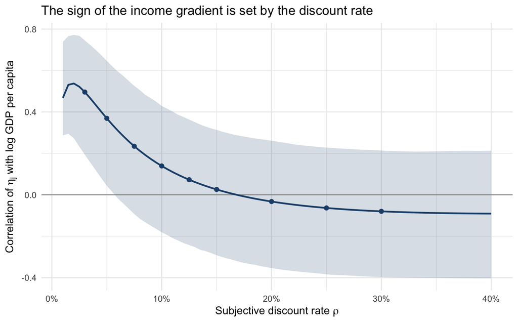

```r
p1 <- ggplot(gradient_fine, aes(rho, correlation)) +
  geom_ribbon(
    data = gradient_band,
    aes(x = rho, ymin = lo, ymax = hi),
    inherit.aes = FALSE,
    fill = "#1F4E79", alpha = 0.18
  ) +
  geom_hline(yintercept = 0, colour = "grey55", linewidth = 0.4) +
  geom_line(linewidth = 0.9, colour = "#1F4E79") +
  geom_point(
    data = gradient_results,
    aes(rho, correlation),
    colour = "#1F4E79", size = 2
  ) +
  scale_x_continuous(labels = percent_format(accuracy = 1)) +
  labs(
    x = expression("Subjective discount rate " * rho),
    y = expression("Correlation of " * eta[j] * " with log GDP per capita"),
    title = "The sign of the income gradient is set by the discount rate"
  ) +
  theme_minimal(base_size = 12)

if (!is.na(rho_star_gdp)) {

  # 95% interval for the crossing itself, shaded behind the red line.
  if (all(is.finite(rho_star_ci))) {
    p1 <- p1 +
      annotate(
        "rect",
        xmin = rho_star_ci[1], xmax = rho_star_ci[2],
        ymin = -Inf, ymax = Inf,
        fill = "red", alpha = 0.10
      )
  }

  p1 <- p1 +
    geom_vline(xintercept = rho_star_gdp, colour = "red", linewidth = 0.8) +
    annotate(
      "text",
      x = rho_star_gdp,
      y = max(gradient_band$hi, gradient_fine$correlation, na.rm = TRUE),
      label = if (all(is.finite(rho_star_ci))) {
        sprintf("  income neutrality: rho* = %.1f%%  [%.1f, %.1f]",
                100 * rho_star_gdp, 100 * rho_star_ci[1], 100 * rho_star_ci[2])
      } else {
        sprintf("  income neutrality: rho* = %.1f%%", 100 * rho_star_gdp)
      },
      hjust = 0, vjust = 1, colour = "red", size = 3.4
    )
}

p1
```

```r
save_figure(p1, "fig1_income_neutrality", width = 8, height = 5)
```

## Figure 2. Mean subjective present value

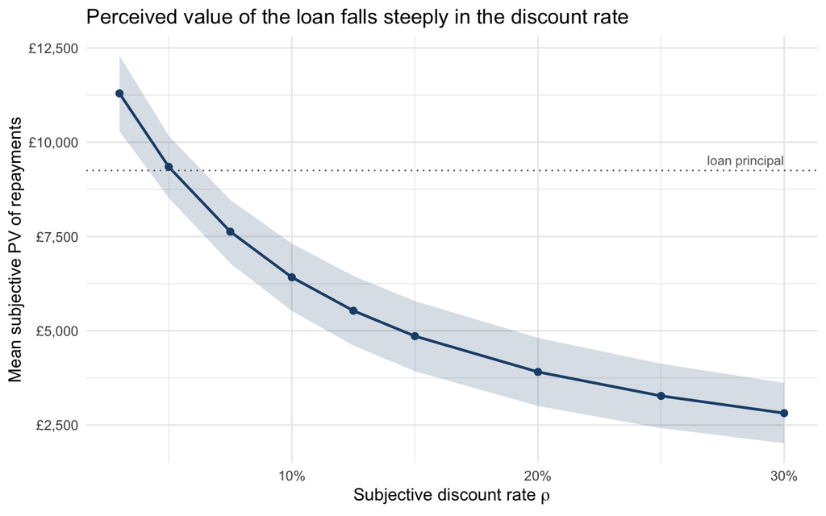

```r
# Interval for the cross-country MEAN PV, not a range for any one country.
pv_band <- results %>%
  group_by(rho) %>%
  summarise(
    mean_PV = mean(PV_subjective),
    se = sd(PV_subjective) / sqrt(n()),
    n = n(),
    .groups = "drop"
  ) %>%
  mutate(
    lo = mean_PV - qt(0.975, n - 1) * se,
    hi = mean_PV + qt(0.975, n - 1) * se
  )

p2 <- ggplot(sweep_summary, aes(rho, mean_PV)) +
  geom_ribbon(
    data = pv_band,
    aes(x = rho, ymin = lo, ymax = hi),
    inherit.aes = FALSE,
    fill = "#1F4E79", alpha = 0.18
  ) +
  geom_line(linewidth = 0.9, colour = "#1F4E79") +
  geom_point(size = 2, colour = "#1F4E79") +
  geom_hline(yintercept = L, linetype = "dotted", colour = "grey40") +
  annotate("text", x = max(sweep_summary$rho), y = L,
           label = "loan principal", hjust = 1, vjust = -0.6,
           size = 3.2, colour = "grey40") +
  scale_x_continuous(labels = percent_format(accuracy = 1)) +
  scale_y_continuous(labels = comma_format(prefix = "\u00a3")) +
  labs(
    x = expression("Subjective discount rate " * rho),
    y = "Mean subjective PV of repayments",
    title = "Perceived value of the loan falls steeply in the discount rate"
  ) +
  theme_minimal(base_size = 12)

p2
```

```r
save_figure(p2, "fig2_mean_subjective_pv", width = 8, height = 5)
```

## Figure 3. Country elasticities across the grid

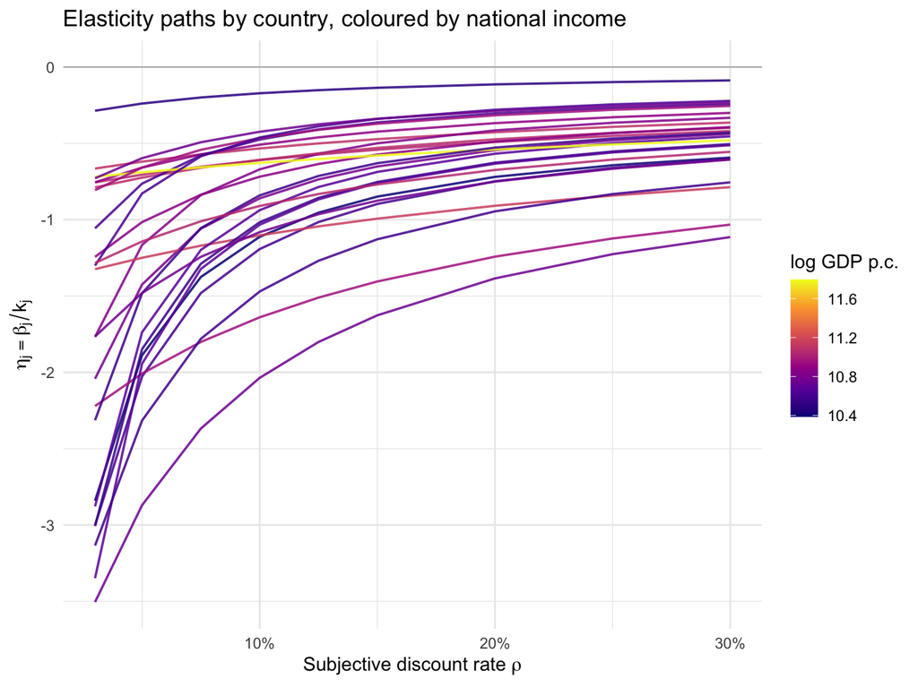

```r
p3 <- results %>%
  left_join(covariates %>% select(iso2c, GDP_PPP_pc), by = "iso2c") %>%
  ggplot(aes(rho, eta_controls, group = Country, colour = log(GDP_PPP_pc))) +
  geom_hline(yintercept = 0, colour = "grey70", linewidth = 0.4) +
  geom_line(alpha = 0.85, linewidth = 0.7) +
  scale_x_continuous(labels = percent_format(accuracy = 1)) +
  scale_colour_viridis_c(option = "C", name = "log GDP p.c.") +
  labs(
    x = expression("Subjective discount rate " * rho),
    y = expression(eta[j] == beta[j] / k[j]),
    title = "Elasticity paths by country, coloured by national income"
  ) +
  theme_minimal(base_size = 12)

p3
```

```r
save_figure(p3, "fig3_country_elasticity_paths", width = 8, height = 6)
```

[figure not shown]

```r
scatter_rhos <- sort(unique(c(
  min(rho_grid),
  if (!is.na(rho_star_gdp)) round(rho_star_gdp, 4) else NULL,
  max(rho_grid)
)))

scatter_dat <- expand_grid(iso2c = dat$iso2c, rho = scatter_rhos) %>%
  left_join(dat, by = "iso2c") %>%
  rowwise() %>%
  mutate(
    PV_subjective = subjective_pv(wage_gbp, lower, upper, rho),
    k_i = log(Ppost) - log(PV_subjective),
    eta_controls = Estimate_controls / k_i
  ) %>%
  ungroup() %>%
  left_join(covariates %>% select(iso2c, log_gdp), by = "iso2c") %>%
  filter(is.finite(log_gdp), is.finite(eta_controls)) %>%
  mutate(panel = paste0("rho = ", percent(rho, accuracy = 0.1)))

p4 <- ggplot(scatter_dat, aes(log_gdp, eta_controls)) +
  geom_smooth(method = "lm", formula = y ~ x, se = TRUE, level = 0.95,
              colour = "red", fill = "red", alpha = 0.12, linewidth = 0.7) +
  geom_point(size = 1.8, colour = "#1F4E79") +
  facet_wrap(~ panel, scales = "free_y") +
  labs(
    x = "log GDP per capita (PPP, constant)",
    y = expression(eta[j]),
    title = "The same coefficients, three discount rates"
  ) +
  theme_minimal(base_size = 12)

p4
```

```r
save_figure(p4, "fig4_cross_section_at_neutrality", width = 8, height = 5)
```

## Figure 5. All covariates

[figure not shown]

```r
neutral_lines <- neutrality_table %>%
  filter(!is.na(rho_star)) %>%
  select(covariate, rho_star)

p5 <- ggplot(alternative_fine, aes(rho, correlation)) +
  geom_ribbon(
    data = alternative_band,
    aes(x = rho, ymin = lo, ymax = hi),
    inherit.aes = FALSE,
    fill = "#1F4E79", alpha = 0.18
  ) +
  geom_hline(yintercept = 0, colour = "grey55", linewidth = 0.4) +
  geom_line(linewidth = 0.8, colour = "#1F4E79") +
  geom_vline(
    data = neutral_lines,
    aes(xintercept = rho_star),
    colour = "red", linewidth = 0.7
  ) +
  facet_wrap(~ covariate, scales = "free_y") +
  scale_x_continuous(labels = percent_format(accuracy = 1)) +
  labs(
    x = expression("Subjective discount rate " * rho),
    y = expression("Correlation with " * eta[j]),
    title = "Which correlations survive the discounting assumption",
    subtitle = "Red line marks a sign change; panels with no red line hold their sign throughout"
  ) +
  theme_minimal(base_size = 11)

p5
```

```r
save_figure(p5, "fig5_alternative_correlations", width = 9.5, height = 7)
```

*Notes.* Shaded regions are 95% percentile bootstrap bands over countries. A panel whose band contains zero across the whole grid supports no claim about that covariate in either direction at any discount rate.

## Saved output

```r
# The numbers behind Figures 1 and 5, so the plotted curves can be checked or
# redrawn without re-running the whole simulation.
write.csv(
  gradient_fine %>% left_join(gradient_band, by = "rho"),
  file.path(fig_dir, "fig1_data_gdp_correlation_by_rho.csv"),
  row.names = FALSE
)
write.csv(
  alternative_fine %>% left_join(alternative_band, by = c("covariate", "rho")),
  file.path(fig_dir, "fig5_data_all_covariate_correlations.csv"),
  row.names = FALSE
)
write.csv(neutrality_table,
          file.path(fig_dir, "neutrality_rates_by_covariate.csv"),
          row.names = FALSE)

manifest <- tibble(file = list.files(fig_dir, full.names = TRUE)) %>%
  mutate(
    size_kb  = round(file.size(file) / 1024, 1),
    modified = file.mtime(file)
  ) %>%
  arrange(file)

manifest
```

| file | size_kb | modified |
| --- | --- | --- |
| figures/fig1_data_gdp_correlation_by_rho.csv | 4.1 | 2026-08-17 14:18:36.331758 |
| figures/fig1_income_neutrality.pdf | 18.2 | 2026-08-17 14:18:32.891707 |
| figures/fig1_income_neutrality.png | 123.6 | 2026-08-17 14:18:32.787611 |
| figures/fig2_mean_subjective_pv.pdf | 16.0 | 2026-08-17 14:18:33.326288 |
| figures/fig2_mean_subjective_pv.png | 148.5 | 2026-08-17 14:18:33.213986 |
| figures/fig3_country_elasticity_paths.pdf | 22.1 | 2026-08-17 14:18:33.812581 |
| figures/fig3_country_elasticity_paths.png | 361.1 | 2026-08-17 14:18:33.756230 |
| figures/fig4_cross_section_at_neutrality.pdf | 24.5 | 2026-08-17 14:18:34.942617 |
| figures/fig4_cross_section_at_neutrality.png | 124.3 | 2026-08-17 14:18:34.861776 |
| figures/fig5_alternative_correlations.pdf | 42.2 | 2026-08-17 14:18:36.204830 |

[output cut: 3 more lines]

```r
cat("\nWrote", nrow(manifest), "files to", normalizePath(fig_dir), "\n")
```

```
##
## Wrote 13 files to /Users/stoycho/Documents/GitHub/Estimating_price_elasticity/Statistical_documentation_in_R/Present_ value_simulations/figures
```

Figures 1 and 5 are the two that carry an argument; 2 to 4 are supporting. If only one goes into the paper it should be Figure 1, since it states the problem in a single line: the sign of the reported income gradient is set by a parameter that has not been defended.